# STAT564 Lab 0: Introduction to R for Simple Linear Regression Analysis

Shen Qu

9/21/2018

## EXAMPLE

These data appeared in the Wall Street Journal. The advertisement were selected by an annual survey conducted by Video Board Tests, Inc., a New York ad-testing company, based on interviews with 20,000 adults who were asked to name the most outstanding TV commercial they had seen, noticed, and liked. The retained impressions were based on a survey of 4,000 adults, in which regular product users were asked to cite a commercial they had seen for that product category in the past week. There are 21 observations on three variables.

**Variables:** Firm The name of the firm Spend TV advertising budget, 1983 ($ millions) MilImp Millions of retained impressions per week

These data is saved in text file (.txt) called **TVads** which will be imported to R as shown in th efollowing code. The path to the place the text file is saved must be changed accordingly.

```r
TVads <- read.table("TVads.txt", header= TRUE)
head(TVads) # This will print only the first 6 rows of data file
```

```
##              Firm Spend MilImp
## 1     MILLER.LITE  50.1   32.1
## 2           PEPSI  74.1   99.6
## 3         STROH'S  19.3   11.7
## 4 FEDERAL.EXPRESS  22.9   21.9
## 5     BURGER.KING  82.4   60.8
## 6       COCO-COLA  40.1   78.6
```

```r
TVads # This will print the complete data file in the Console Window
```

```
##               Firm Spend MilImp
## 1      MILLER.LITE  50.1   32.1
## 2            PEPSI  74.1   99.6
## 3          STROH'S  19.3   11.7
## 4  FEDERAL.EXPRESS  22.9   21.9
## 5      BURGER.KING  82.4   60.8
## 6        COCO-COLA  40.1   78.6
## 7      MC.DONALD'S 185.9   92.4
## 8              MCI  26.9   50.7
## 9        DIET.COLA  20.4   21.4
## 10            FORD 166.2   40.1
## 11          LEVI'S  27.0   40.8
## 12        BUD.LITE  45.6   10.4
## 13        ATT.BELL 154.9   88.9
## 14    CALVIN.KLEIN   5.0   12.0
## 15         WENDY'S  49.7   29.2
## 16        POLAROID  26.9   38.0
## 17          SHASTA   5.7   10.0
## 18        MEOW.MIX   7.6   12.3
## 19     OSCAR.MEYER   9.2   23.4
## 20           CREST  32.4   71.1
## 21  KIBBLES.N.BITS   6.1    4.4
```

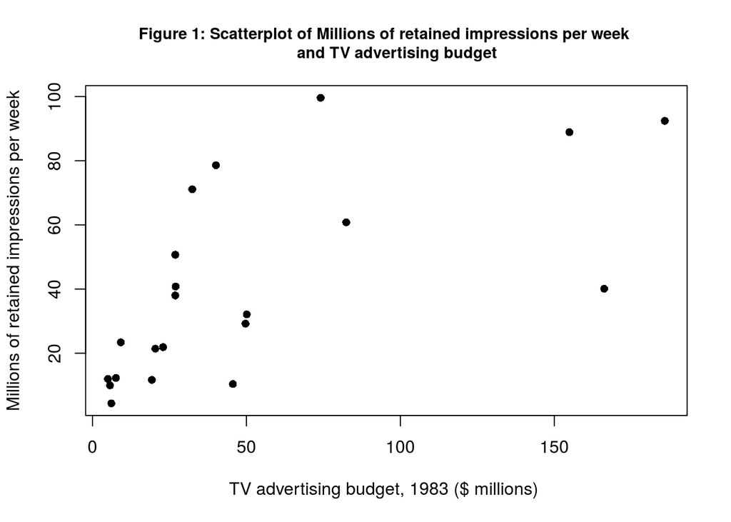

```r
# The following plot function creates the scatterplot shown in Figure 1 below
plot(TVads$Spend, TVads$MilImp, pch=16, xlab = "TV advertising budget, 1983 ($ millions) ", ylab = "Millions of retained impressions per week", main="Figure 1: Scatterplot of Millions of retained impressions per week
     and TV advertising budget", cex.main=0.9)
```

Simple linear regression analysis in R

```r
model <- lm(MilImp ~ Spend, data = TVads) # The lm function is used to fit simple linear regression model
model# This displays only the values of estimated regression coefficients
```

```
##
## Call:
## lm(formula = MilImp ~ Spend, data = TVads)
##
## Coefficients:
## (Intercept)        Spend
##     22.1627       0.3632
```

```r
summary(model) # The summary function is used to get more information about the fitted regression model #
```

```
##
## Call:
## lm(formula = MilImp ~ Spend, data = TVads)
##
## Residuals:
##     Min      1Q  Median      3Q     Max
## -42.422 -12.623  -8.171   8.832  50.526
##
## Coefficients:
##             Estimate Std. Error t value Pr(>|t|)
## (Intercept) 22.16269    7.08948   3.126  0.00556 **
## Spend        0.36317    0.09712   3.739  0.00139 **
## ---
## Signif. codes:  0 '***' 0.001 '**' 0.01 '*' 0.05 '.' 0.1 ' ' 1
##
## Residual standard error: 23.5 on 19 degrees of freedom
## Multiple R-squared:  0.424,  Adjusted R-squared:  0.3936
## F-statistic: 13.98 on 1 and 19 DF,  p-value: 0.001389
```

The output shows estimated regression coefficients, their standard errors (deviations), test statistics & p-value for testing significance. Also, there is R squared, degrees of freedom and F test statistic for testing significance of fitted model. You can use the abline function as shown below to plot the fitted regression model on the scatterplot.

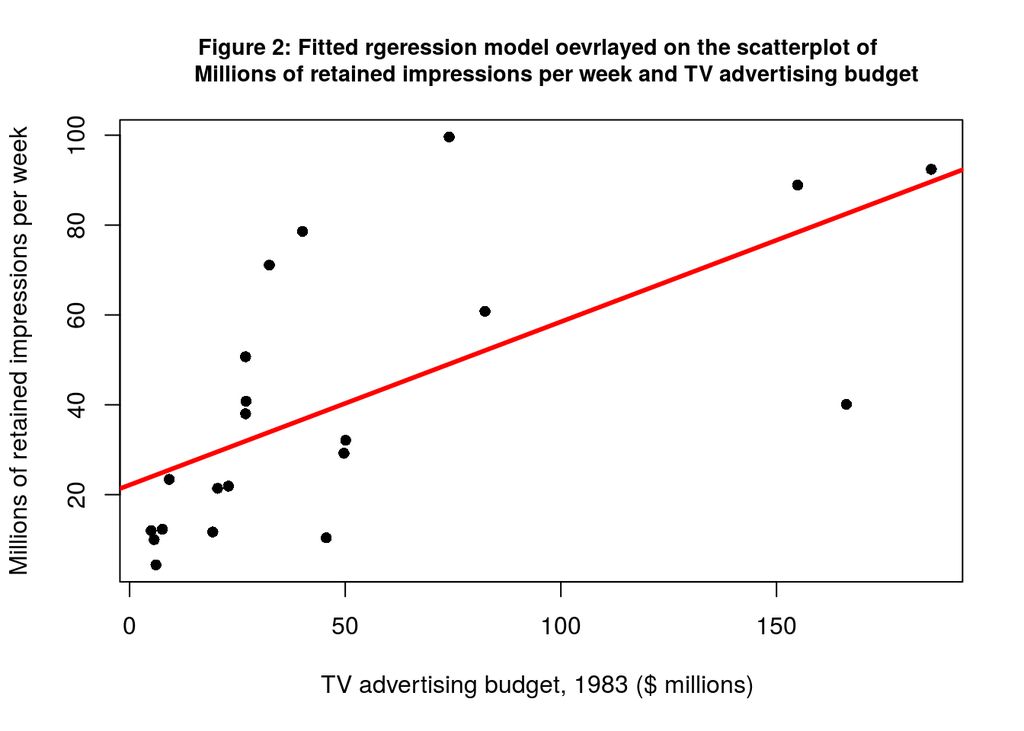

```r
plot(TVads$Spend, TVads$MilImp, pch=16, xlab = "TV advertising budget, 1983 ($ millions) ", ylab = "Millions of retained impressions per week", main="Figure 2: Fitted rgeression model oevrlayed on the scatterplot of
     Millions of retained impressions per week and TV advertising budget", cex.main=0.9) # Create the scatterplot
abline(model, col = "red", lwd= 3) # Draw the fitted line #
```

The 95% CI for parameter estimates can be obtained using the following function:

```r
confint(model, level = 0.95)
```

```
##                2.5 %     97.5 %
## (Intercept) 7.324244 37.0011425
## Spend       0.159899  0.5664492
```

The 95% confidence interval for slope of the regression line is (0.1599, 0.5664). If you want to get the predicted value of response for each value of predictor, then use the **predict** function as shown below.

```r
predict(model, TVads)
```

```
##        1        2        3        4        5        6        7        8        9       10       11       12       13       14       15       16       17       18       19       20       21
## 40.35771 49.07389 29.17195 30.47938 52.08824 36.72597 89.67675 31.93208 29.57144 82.52222 31.96839 38.72343 78.41836 23.97856 40.21244 31.93208 24.23279 24.92282 25.50389 33.92953 24.37806
```

This same function can be used to get prediction interval for the each value of predictor as shown below.

```r
predict(model, TVads, interval = "prediction", level = 0.95)
```

```
##         fit        lwr       upr
## 1  40.35771  -9.989125  90.70455
## 2  49.07389  -1.502881  99.65067
## 3  29.17195 -21.570203  79.91411
## 4  30.47938 -20.176808  81.13557
## 5  52.08824   1.322964 102.85351
## 6  36.72597 -13.664345  87.11629
## 7  89.67675  32.288077 147.06543
## 8  31.93208 -18.640841  82.50499
## 9  29.57144 -21.143338  80.28623
## 10 82.52222  26.944377 138.10007
## 11 31.96839 -18.602607  82.53939
## 12 38.72343 -11.632825  89.07969
## 13 78.41836  23.773745 133.06297
## 14 23.97856 -27.207071  75.16420
## 15 40.21244 -10.134558  90.55945
## 16 31.93208 -18.640841  82.50499
## 17 24.23279 -26.927385  75.39296
## 18 24.92282 -26.170173  76.01581
## 19 25.50389 -25.534718  76.54251
## 20 33.92953 -16.550051  84.40912
## 21 24.37806 -26.767737  75.52385
```

You may want to compute prediction values of response for a given set of new values of predictor. In that case, first, create a new data file with the new value of predictor. Then use the predictor function to predict response as shown below. Here, our new values of the Spend variable are 50 and 100.

```r
NewData <- data.frame(Spend = c(50, 100)) # Creates a new data frame with only new values of predictor variable
predict(model, NewData, interval = "prediction", level = 0.95) # Use the new data frame in the Predictor function instead of old data set
```

```
##       fit        lwr       upr
## 1 40.3214 -10.025471  90.66826
## 2 58.4801   7.133667 109.82653
```

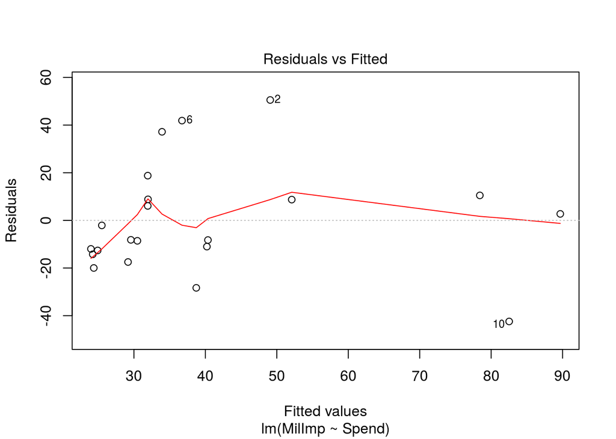

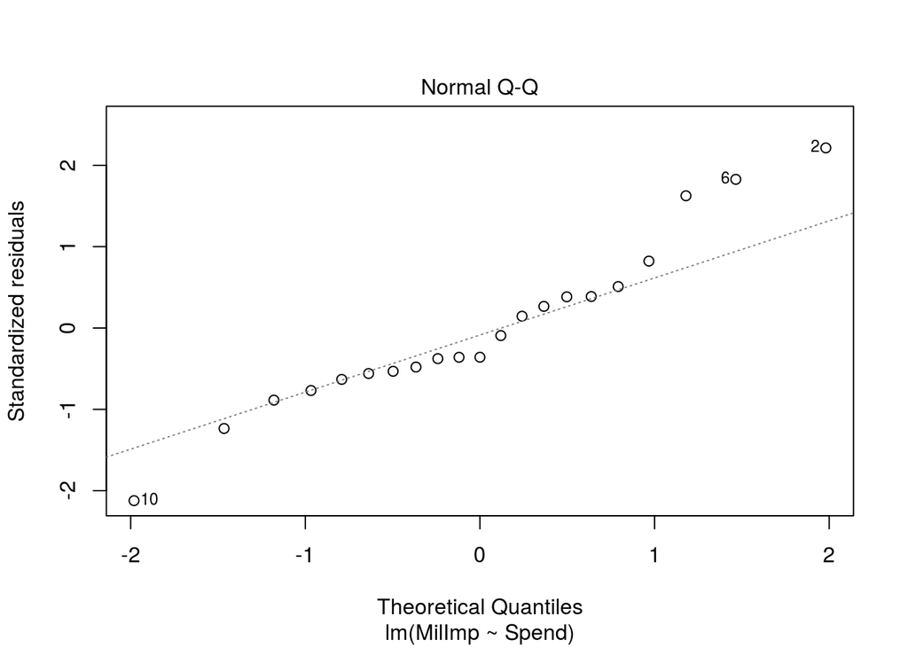

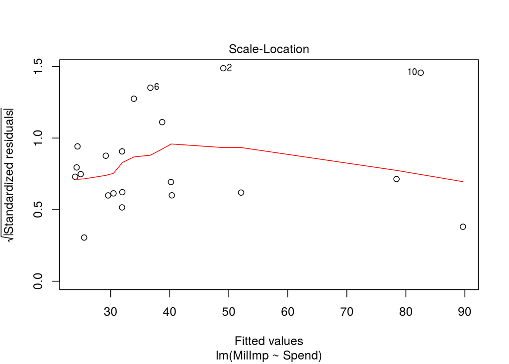

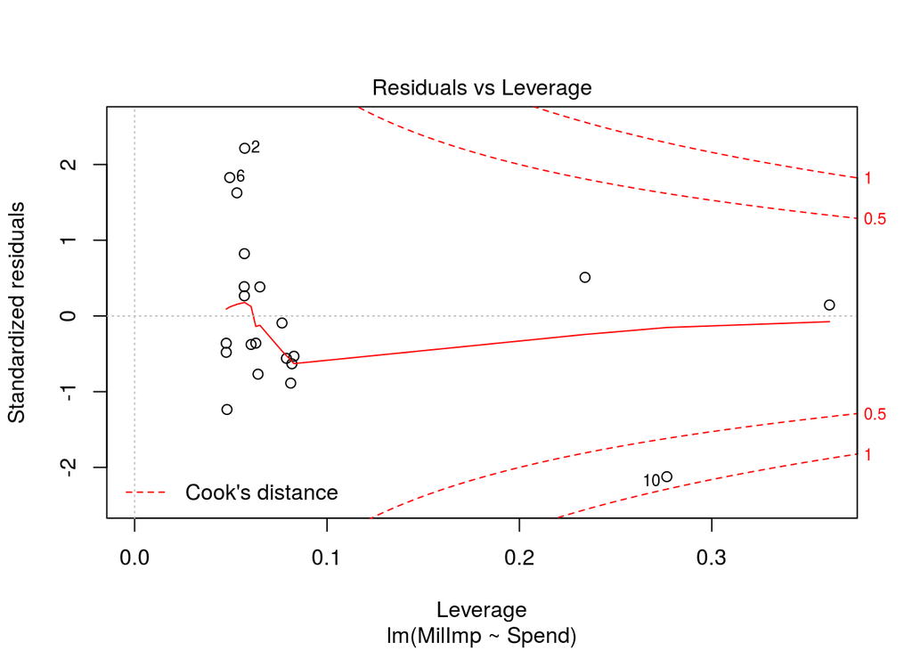

```r
plot(model) # This plots the diagnostic graphs for the fitted regression model. Fit enter key 4 times to see the plots shown below #
```

When you want to do multiple linear regression in R, you can add other predictors to the lm function each separated by a plus sign.

## The Solution by tidyverse

```r
install.packages("tidyverse")
```

To use R packages you have installed, include this line in your script or in the Console:

```r
library("tidyverse")
# Note here the quotation marks are optional and
# it is the same as
library(tidyverse)
```

### Import Data

1. Download the data file here .
2. What format is the data file in?
3. Import the data in the file into R as a data frame:

```r
my_df <- read_table2("TVads.txt")
my_df
```

```
## # A tibble: 21 x 3
##    Firm            Spend MilImp
##    <chr>           <dbl>  <dbl>
##  1 MILLER.LITE      50.1   32.1
##  2 PEPSI            74.1   99.6
##  3 STROH'S          19.3   11.7
##  4 FEDERAL.EXPRESS  22.9   21.9
##  5 BURGER.KING      82.4   60.8
##  6 COCO-COLA        40.1   78.6
##  7 MC.DONALD'S     186     92.4
##  8 MCI              26.9   50.7
##  9 DIET.COLA        20.4   21.4
## 10 FORD            166     40.1
## # ... with 11 more rows
```

Of course, the step of import data into your statistic software vary a little by software and by the data format.

More information as of how to import data into R can be found at Import Data

### Descriptive Statistics

#### Visualization

1. Visualize a single variable

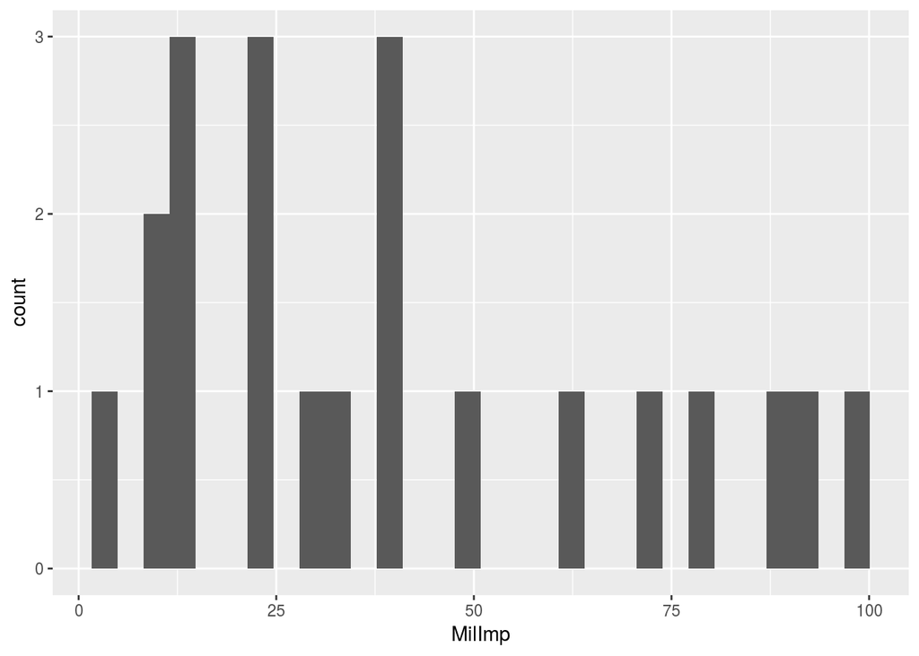

```r
ggplot(my_df, aes(x=MilImp)) + geom_histogram()
```

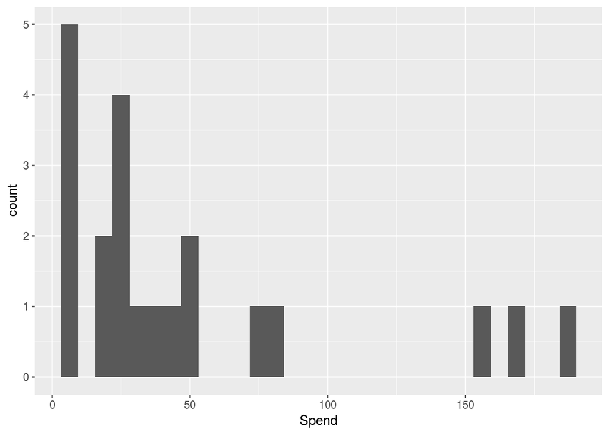

```r
ggplot(my_df, aes(x=Spend)) + geom_histogram()
```

2. Visualize a pair of numeric variables

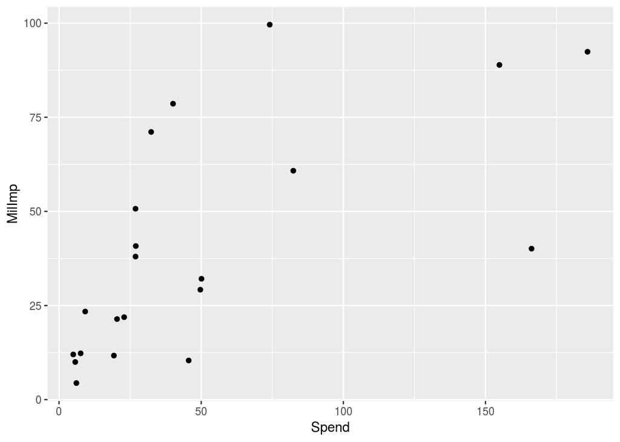

```r
ggplot(my_df, aes(x=Spend, y=MilImp)) + geom_point()
```

### Correlation

```r
cor(my_df$MilImp, my_df$Spend)
```

```
## [1] 0.6511151
```

### Regression

In R, run linear regressions with `lm` (short for **l**inear **m**odel):

```r
lm(MilImp ~ Spend, data=my_df)
```

```
##
## Call:
## lm(formula = MilImp ~ Spend, data = my_df)
##
## Coefficients:
## (Intercept)        Spend
##     22.1627       0.3632
```

### More detailed regression results

1. Pass the results from `lm()` to `summary()` for more detailed information:

```r
lm(MilImp ~ Spend, data=my_df) %>%
  summary
```

```
##
## Call:
## lm(formula = MilImp ~ Spend, data = my_df)
##
## Residuals:
##     Min      1Q  Median      3Q     Max
## -42.422 -12.623  -8.171   8.832  50.526
##
## Coefficients:
##             Estimate Std. Error t value Pr(>|t|)
## (Intercept) 22.16269    7.08948   3.126  0.00556 **
## Spend        0.36317    0.09712   3.739  0.00139 **
## ---
## Signif. codes:  0 '***' 0.001 '**' 0.01 '*' 0.05 '.' 0.1 ' ' 1
##
## Residual standard error: 23.5 on 19 degrees of freedom
## Multiple R-squared:  0.424,  Adjusted R-squared:  0.3936
## F-statistic: 13.98 on 1 and 19 DF,  p-value: 0.001389
```

For better formatting of the results (pretty print), we can use the `texreg` package:

```r
## Install and load texreg package
install.packages("texreg")
library(texreg)

# Pretty print regression results on screen
lm(MilImp ~ Spend, data=my_df) %>%
  screenreg
```

```
##
## =====================
##              Model 1
## ---------------------
## (Intercept)  22.16 **
##              (7.09)
## Spend         0.36 **
##              (0.10)
## ---------------------
## R^2           0.42
## Adj. R^2      0.39
## Num. obs.    21
## RMSE         23.50
## =====================
## *** p < 0.001, ** p < 0.01, * p < 0.05
```

```r
# Save regression results to a html file
lm(MilImp ~ Spend, data=my_df) %>%
  htmlreg(file="lm_MilImp-Spend.html")
```

### Visualize regression results

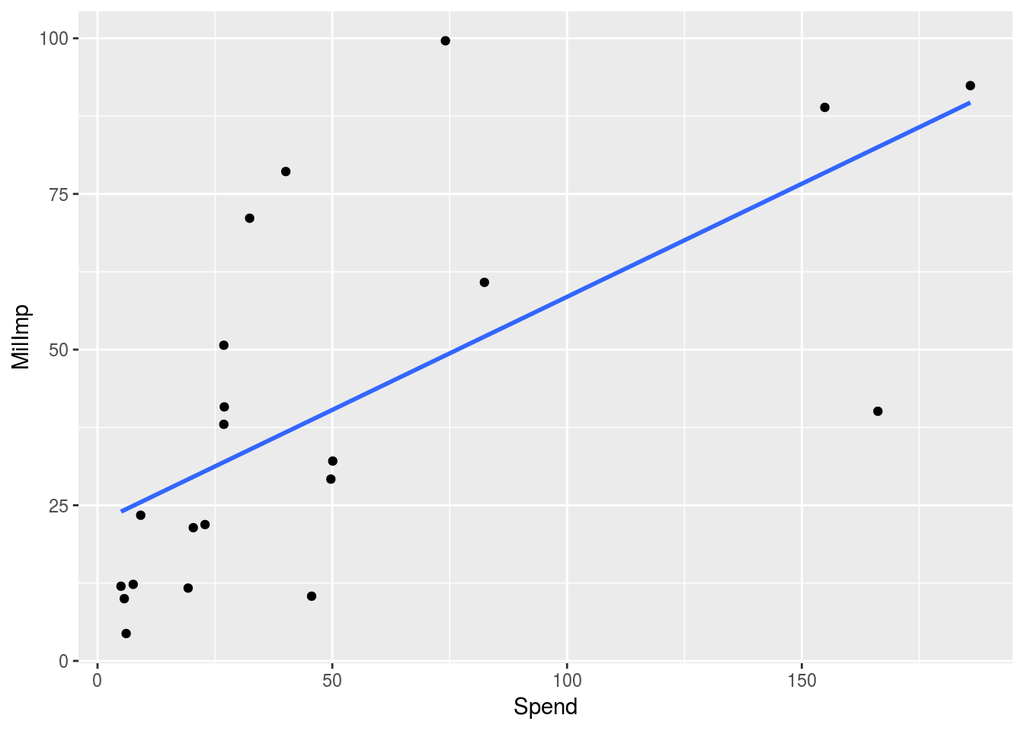

```r
ggplot(my_df, aes(x=Spend, y=MilImp)) + geom_point() + geom_smooth(method = "lm", se = FALSE)
```

### Diagnostic plots of regression

We will use the `ggfortify` package to generate the diagnostic plots for regression

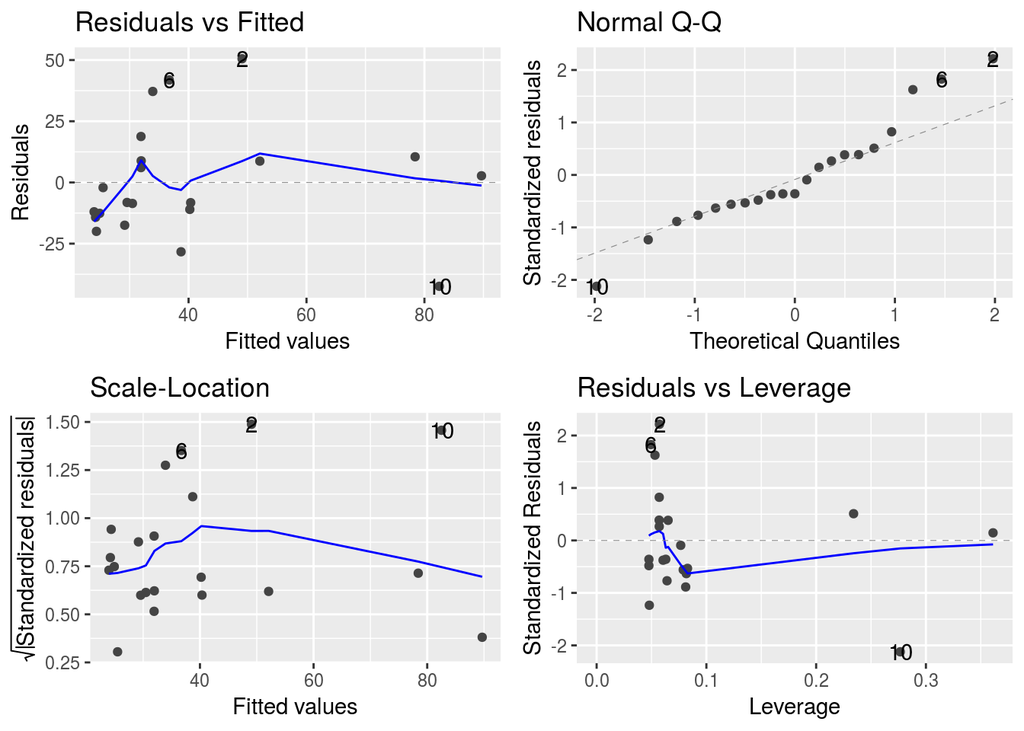

```r
## Install and load ggfortify package
install.packages("ggfortify")
library(ggfortify)

lm(MilImp ~ Spend, data=my_df) %>%
  autoplot()
```

```r
# Since we need the regression results in many places,
# it would be easier to save it into a R variable
MilImp_lm <- lm(MilImp ~ Spend, data=my_df)

# Save the diagnostic plots as a png file
ggsave("MilImp_lm_diag.png")
```

## Resources

- [Introduction to R on Data Camp](https://campus.datacamp.com/courses/free-introduction-to-r/chapter-1-intro-to-basics-1?ex=1): A self-instruction course covering R basics.
- [R coding basics on Software Carpentry](http://swcarpentry.github.io/r-novice-gapminder/), hands-on tutorial on R basics, lesson 4-11.